# Mushroom Classifier

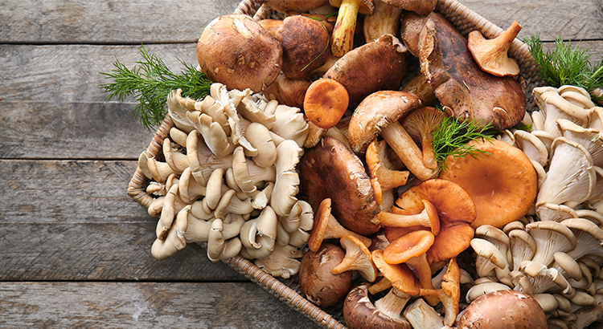

# Introduction

This is a dataset of mushrooms and 23 characteristics, and 23 species of mushroom ($N=8124$). The dataset is available on this repo, but is also available with more information from [here](https://www.kaggle.com/uciml/mushroom-classification/data).

**Dataset feature summary:**

- `safe` : classes: edible=e, poisonous=p
- `cap-shape` : bell=b,conical=c,convex=x,flat=f, knobbed=k,sunken=s
- `cap-surface` : fibrous=f,grooves=g,scaly=y,smooth=s
- `cap-color`: brown=n,buff=b,cinnamon=c,gray=g,green=r,pink=p,purple=u,red=e,white=w,yellow=y
- `bruises`: bruises=t,no=f
- `odor`: almond=a,anise=l,creosote=c,fishy=y,foul=f,musty=m,none=n,pungent=p,spicy=s
- `gill-attatchment` : attached=a,descending=d,free=f,notched=n
- `gill-spacing` : close=c,crowded=w,distant=d
- `gill-size` : broad=b,narrow=n
- `gill-color` : black=k,brown=n,buff=b,chocolate=h,gray=g, green=r,orange=o,pink=p,purple=u,red=e,white=w,yellow=y
- `stalk-shape` : enlarging=e,tapering=t
- `stalk-root` : bulbous=b,club=c,cup=u,equal=e,rhizomorphs=z,rooted=r,missing=?
- `stalk-surface-above-ring` : fibrous=f,scaly=y,silky=k,smooth=s
- `stalk-surface-below-ring` : fibrous=f,scaly=y,silky=k,smooth=s
- `stalk-color-above-ring` : brown=n,buff=b,cinnamon=c,gray=g,orange=o,pink=p,red=e,white=w,yellow=y
- `stalk-color-below-ring` : brown=n,buff=b,cinnamon=c,gray=g,orange=o,pink=p,red=e,white=w,yellow=y
- `veil-type` : partial=p,universal=u
- `veil-color` : brown=n,orange=o,white=w,yellow=y
- `ring-number` : none=n,one=o,two=t
- `ring-type` : cobwebby=c,evanescent=e,flaring=f,large=l,none=n,pendant=p,sheathing=s,zone=z
- `spore-print-color` : black=k,brown=n,buff=b,chocolate=h,green=r,orange=o,purple=u,white=w,yellow=y
- `population` : abundant=a,clustered=c,numerous=n,scattered=s,several=v,solitary=y
- `habitat` : grasses=g,leaves=l,meadows=m,paths=p,urban=u,waste=w,woods=d

# Exploratory Data Analysis

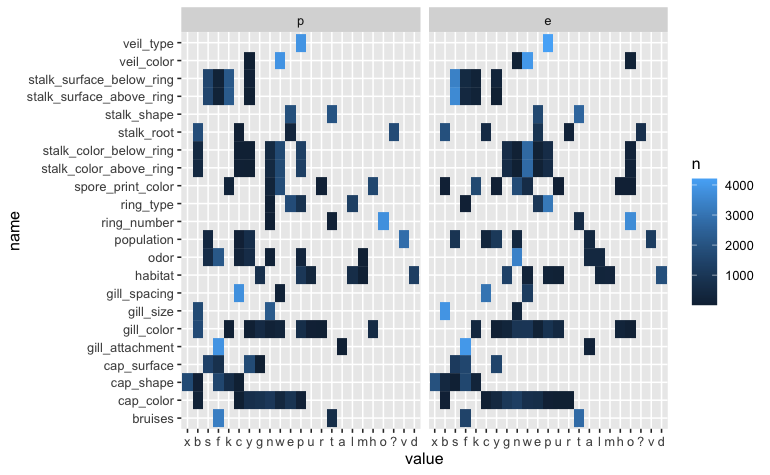

# Edible or Not?

I think a nice natural choice for this problem would be a tree based problem. A decision tree is very easy for anyone to interpret and would be the best choice to help pick if a mushrooms is edible or not.

For our first go, we will build a plain decision tree and see how it does. I’ll use an 80/20 train-test split for our data.

```r
set.seed(23)
# Get 80% of the data for training.
train_df <- sample_n(mushrooms,
                     size = round(nrow(mushrooms)*0.8),
                     replace = F)

# Get remaining observations for test set.
test_df <- anti_join(mushrooms, train_df)
```

```r
library(tree)
d_tree_1 <- tree(formula = safe ~ . ,data = train_df)

summary(d_tree_1)
```

```
Classification tree:
tree(formula = safe ~ ., data = train_df)
Variables actually used in tree construction:
[1] "odor"                   "spore_print_color"      "stalk_color_below_ring"
[4] "stalk_root"
Number of terminal nodes:  5
Residual mean deviance:  0.01156 = 75.09 / 6494
Misclassification error rate: 0.0007693 = 5 / 6499
```

Now, to assess our tree’s performance.

```r
# 3 incorrect for the test set! Uh oh!
sum(!(test_results$eat == test_df$safe))
```

```
[1] 3
```